# Correlation matrix calculation using R.VALUE: A worked example (*version 2*)

Santander MetGroup

February 18, 2016

# 1. Introduction

This is a worked example on how to compute correlation matrices from the outputs of the different VALUE experiments and datasets. `corrMat.VALUE` is a specific function to this aim, as part of the R.VALUE package for data validation. The main features have been discussed previously by the validation paper working group, and have been implemented as arguments of the function. As a result, different correlation methods can be indicated (e.g. pearson for temperatures and spearman for precipitation). A (circular) moving average daily climatology can be automatically calculated for each data series, considering a specific window width (60 days by default, centered around lag 0). This is used for removing the seasonal cycles when applicable. An additional argument allows to specify the maximum number of missing values allowed, being ommited from the analysis those data series above the threshold.

The function corrMat.VALUE is intended to handle the predictions files as directly downloaded from the VALUE validation portal, without the need of further preprocessing.

## 1.1. Installing R.VALUE

R.VALUE is available on GitHub. The most direct way of installing the package is using the `install_github` function from package devtools. Note that a special development branch called *spvalPaper* has been created for testing purposes, aimed at containing different functions developed for the spatial validation paper before these are agreed to be included in the master branch.

```r
require(devtools)
install_github("SantanderMetGroup/R_VALUE")
```

## 1.2. Example datasets (observations and predictions)

Tha data from the different experiments already available can be downloaded from the VALUE-COST Validation Portal, under the [Validation Tab](http://www.value-cost.eu/validationportal/app#!results) (requires a valid username and password for access). The option “*Download prediction*” must be chosen. All experiments have an associated observational dataset, as indicated in the [Experiments Table](http://www.value-cost.eu/validationportal/app#!experiments).

In this example, we will use the predictions from **Experiment_1a**. In particular, the outputs of the direct analogs method. For the sake of example reproducibility, both the reference station datasets (*VALUE_ECA_86_v2*) and two predictions zip files (deterministic and stochastic) as directly downloaded from the portal[^1], have been included in the installation of the `R.VALUE` package.

Path to the *VALUE_ECA_86_v2* dataset (this will vary depending on the installation directory):

```r
# Path to ECA dataset file
obs.file <- file.path(find.package("R.VALUE"), "example_datasets", "VALUE_ECA_86_v2.zip")
```

Path to the predictions datasets (this will vary depending on the installation directory):

```r
# Display paths to predictions files
list.files(file.path(find.package("R.VALUE"), "example_datasets"),
           pattern = "predictions_portal_exp1a",
           full.names = TRUE)
```

First of all, the reference observations need to be loaded. This object will serve as reference for loading the different prediction files and perform all the internal operations for an exact data collocation. All the examples are given for minimum temperature:

## 1.3. Loading observations

Observational datasets are loaded with the `loadValueStations` function. The function is documented thruogh the R help menu.

```r
obs <- loadValueStations(obs.file, var = "tmin")
```

```r
## [2016-02-14 11:06:40] Loading data ...
## [2016-02-14 11:06:53] Retrieving metadata ...
## [2016-02-14 11:06:53] Done.
```

```r
str(obs)
```

```
## List of 5
##  $ Variable:List of 1
##   ..$ varName: chr "tmin"
##  $ Data    : num [1:18262, 1:86] -4.7 -1.2 -4.3 0.8 0.8 -4.4 -4 -4.2 -2 -3 ...
##   ..- attr(*, "dimensions")= chr [1:2] "time" "station"
##  $ xyCoords: num [1:86, 1:2] 15.4 11.4 13 12.9 16.4 ...
##   ..- attr(*, "dimnames")=List of 2
##   .. ..$ : chr [1:86] "000012" "000013" "000014" "000015" ...
##   .. ..$ : chr [1:2] "longitude" "latitude"
##  $ Dates   :List of 2
##   ..$ start: chr [1:18262] "1961-01-01 00:00:00" "1961-01-02 00:00:00" "1961-01-03 00:00:00" "1961-01-04 00:00:00" ...
##   ..$ end  : chr [1:18262] "1961-01-02 00:00:00" "1961-01-03 00:00:00" "1961-01-04 00:00:00" "1961-01-05 00:00:00" ...
##  $ Metadata:List of 4
##   ..$ station_id: chr [1:86] "000012" "000013" "000014" "000015" ...
##   ..$ name      : chr [1:86] "GRAZ" "INNSBRUCK" "SALZBURG" "SONNBLICK" ...
##   ..$ altitude  : int [1:86] 366 577 437 3106 198 100 156 4 139 179 ...
##   ..$ source    : chr [1:86] "ECA&D" "ECA&D" "ECA&D" "ECA&D" ...
```

## 1.4. Loading predictions

Predictions are loaded with the `loadValuePredictions` function (see help `loadValuePredictions` for further details). However, this will be internally done by `corrMat.VALUE` if we specify a path to the predictions file via the `predictions.file` argument. Otherwise, the correlation matrix will be undertaken on the observational dataset, as illustrated in the next section. Nevertheless, an example on loading a stochastic predictions file (as downloaded from the VALUE validation portal) is next shown:

```r
# Path to built-in example predictions file
prdfile <- list.files(file.path(find.package("R.VALUE"), "example_datasets"),
                      pattern = "predictions_portal_exp1a_stochastic",
                      full.names = TRUE)
pred <- loadValuePredictions(stationObj = obs, predictions.file = prdfile)
```

```r
## Warning message:
## In getTimeDomainValueStations(timeDates, season, years) :
##   Year selection out of dataset range. Only available years will be returned
```

```r
str(pred)
```

```
## List of 5
##  $ Variable:List of 1
##   ..$ varName: chr "tmin"
##  $ xyCoords: num [1:86, 1:2] 15.4 11.4 13 12.9 16.4 ...
##   ..- attr(*, "dimnames")=List of 2
##   .. ..$ : chr [1:86] "000012" "000013" "000014" "000015" ...
##   .. ..$ : chr [1:2] "longitude" "latitude"
##  $ Dates   :List of 2
##   ..$ start: chr [1:10958] "1979-01-01 00:00:00" "1979-01-02 00:00:00" "1979-01-03 00:00:00" "1979-01-04 00:00:00" ...
##   ..$ end  : chr [1:10958] "1979-01-02 00:00:00" "1979-01-03 00:00:00" "1979-01-04 00:00:00" "1979-01-05 00:00:00" ...
##  $ Metadata:List of 4
##   ..$ station_id: chr [1:86] "000012" "000013" "000014" "000015" ...
##   ..$ name      : chr [1:86] "GRAZ" "INNSBRUCK" "SALZBURG" "SONNBLICK" ...
##   ..$ altitude  : int [1:86] 366 577 437 3106 198 100 156 4 139 179 ...
##   ..$ source    : chr [1:86] "ECA&D" "ECA&D" "ECA&D" "ECA&D" ...
##  $ Data    : num [1:10, 1:10958, 1:86] 6.38 2.5 1.09 6.6 15.47 ...
##   ..- attr(*, "dimensions")= chr [1:3] "member" "time" "station"
##  - attr(*, "datatype")= chr "predictions"
```

# 2. Correlation matrices

## 2.1. Correlation matrix of the observations:

Note that some of these arguments may be ommited as they correspond to the default values. For further information see `help("corrMat.VALUE")`

```r
a <- corrMat.VALUE(stationObj = obs,
                   season = "annual",
                   max.na.prop = 0.25,
                   predictions.file = NULL,
                   method = "pearson",
                   deseason = TRUE,
                   window.width = 60)
```

```r
## [2016-02-15 10:48:22] - Removing seasonal cycle...
## [2016-02-15 10:48:49] - Done.
```

The correlation matrix holds the necessary attributes for spatial collocation and axes labelling:

```r
str(a)
```

```
##  num [1:84, 1:84] 1 0.82 0.859 0.687 0.911 ...
##  - attr(*, "dimnames")=List of 2
##   ..$ : NULL
##   ..$ : NULL
##  - attr(*, "station_names")= chr [1:84] "GRAZ" "INNSBRUCK" "SALZBURG" "SONNBLICK" ...
##  - attr(*, "lon")= Named num [1:84] 15.4 11.4 13 12.9 16.4 ...
##   ..- attr(*, "names")= chr [1:84] "000012" "000013" "000014" "000015" ...
##  - attr(*, "lat")= Named num [1:84] 47.1 47.3 47.8 47 48.2 ...
##   ..- attr(*, "names")= chr [1:84] "000012" "000013" "000014" "000015" ...
```

## 2.2. Correlation matrix of predictions

```r
b <- corrMat.VALUE(stationObj = obs,
                   predictions.file = prdfile,
                   season = "annual",
                   max.na.prop = 0.25,
                   method = "pearson",
                   deseason = TRUE,
                   window.width = 30)
```

```r
## [2016-02-15 10:56:27] - Loading predictions...
## [2016-02-15 10:56:29] - Done.
## [2016-02-15 10:56:36] - Removing seasonal cycle...
## [2016-02-15 10:56:52] - Done.
```

```r
str(b)
```

```
##  num [1:86, 1:86] 1 0.934 0.91 0.723 0.922 ...
##  - attr(*, "dimnames")=List of 2
##   ..$ : NULL
##   ..$ : NULL
##  - attr(*, "station_names")= chr [1:86] "GRAZ" "INNSBRUCK" "SALZBURG" "SONNBLICK" ...
##  - attr(*, "lon")= Named num [1:86] 15.4 11.4 13 12.9 16.4 ...
##   ..- attr(*, "names")= chr [1:86] "000012" "000013" "000014" "000015" ...
##  - attr(*, "lat")= Named num [1:86] 47.1 47.3 47.8 47 48.2 ...
##   ..- attr(*, "names")= chr [1:86] "000012" "000013" "000014" "000015" ...
```

### 2.2.2. Correlation matrix of stochastic predictions

The process is similar, but in this case there is an optional argument in order to indicate whether the different realizations should be aggregated before computing the correlations (also before computing the optional removal of the seasonal cycle), or fater computing the correlations (i.e., aggregation of the correlation coefficients for each realization). Two examples follow:

```r
prdfile.stoch <- list.files(file.path(find.package("R.VALUE"), "example_datasets"),
                            pattern = "predictions_portal_exp1a_stochastic",
                            full.names = TRUE)
```

All members are aggregated *before* computing the correlation:

```r
c.before <- corrMat.VALUE(stationObj = obs,
                          predictions.file = prdfile.stoch,
                          season = "DJF",
                          type = "before",
                          max.na.prop = 0.25,
                          method = "pearson",
                          deseason = TRUE,
                          window.width = 30)
```

```r
## [2016-02-15 11:31:22] - Loading predictions...
## [2016-02-15 11:31:43] - Done.
## [2016-02-15 11:31:43] - Aggregating members before computing correlation...
## [2016-02-15 11:31:45] - Done.
## [2016-02-15 11:31:45] - Removing seasonal cycle...
## [2016-02-15 11:31:46] - Done.
```

The same method, but all members are aggregated *after* computing the correlation:

```r
c.after <- corrMat.VALUE(stationObj = obs,
                          predictions.file = prdfile.stoch,
                          season = "DJF",
                          type = "after",
                          max.na.prop = 0.25,
                          method = "pearson",
                          deseason = TRUE,
                          window.width = 30)
```

```r
## [2016-02-15 11:33:21] - Loading predictions...
## [2016-02-15 11:33:43] - Done.
## [2016-02-15 11:33:43] - Removing seasonal cycle...
## [2016-02-15 11:33:57] - Done.
```

## 2.3. Plotting correlations

The following example compares the result from the two types of aggregation (it requires the R package `lattice`):

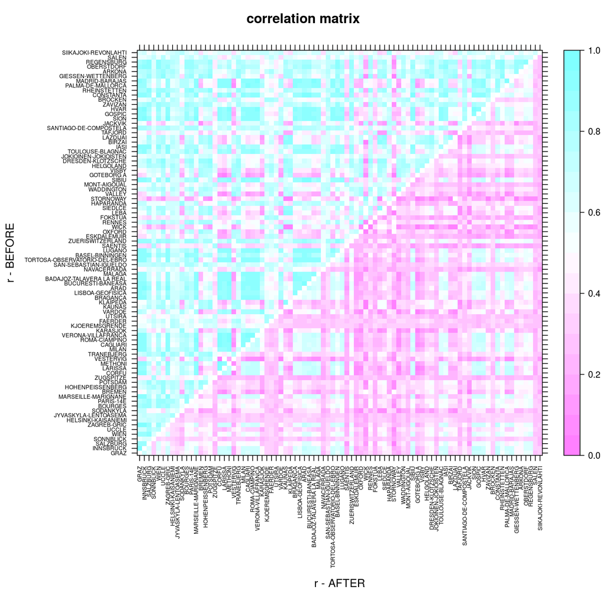

Fig. 1. Correlation matrix of stochastic predictions. Two types of aggregations are compared.

```r
c.before[lower.tri(c.before)] <- c.after[lower.tri(c.after)]
diag(c.before) <- NA
# Graphic pars
station.labels <- attr(c.before, "station_names")
scales.list <- list(x = list(labels = station.labels, rot = 90,
                             at = seq(1,ncol(c.before),1), cex = .5),
                    y = list(labels = station.labels,
                             at = seq(1,ncol(c.before),1), cex = .5))
require(lattice)
levelplot(c.before, xlab = "r - AFTER", ylab = "r - BEFORE", main = "correlation matrix",
          scales = scales.list, at = seq(0,1,.05))
```

[^1]: However note that the stochastic predictions file has been modified in order to hold just 10 members instead of 100, for package size.